# Data Science Capstone - Word Prediction App "Sparrow"

Claus Walter  
08.06.2017

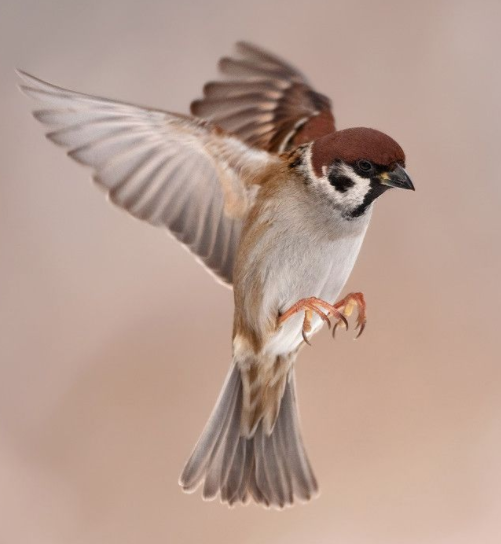

### Introduction

Sparrow is a R/Shiny-based text prediction app. Special features:

- It learns abou you - it remembers what you entered and will use that for future predictions!
- It is fast - although there is certainly a trade-off between speed and accuracy
- It can handle “odd” input values like e.g. things you would find in tweets or blogs. So not necessarily Oxford-English ;-)
- It shows the data it uses for predictions, so you can see it “think” - in a certain way
- It is small - less than 30 MB, so it can squeeze into almost any device
- It finds a swearword it knows, it just shows ***** - so it behaves nicely

### How to use Sparrow

Sparrow follows a very simple approach, by following these steps (as also shown in the picture):

1. Enter text
2. Press “Predict” button and check prediction result
3. Take prediction over (paste) into input field (if you want)

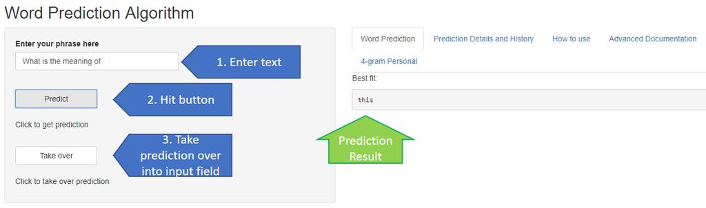

   Many more details under the tabs “How to use” and “Advanced Documentation” inside the application.

### References

Here the references to the coding, the presentation and the app:

Sparrow application: https://clauswalter.shinyapps.io/DataScienceCapstoneApplication/

Github: https://github.com/ClausWalter/CapstoneDataScienceFinal

This presentation: http://rpubs.com/ClausWalter/Capstone